# Sampling distributions

In this lab we will

- take some random samples and
- build sampling distributions
> - investigate the ways in which the statistics from a random sample of data can serve as point estimates for population parameters.
> - formulate a *sampling distribution* of our estimate in order to learn about the properties of the estimate, such as its distribution.

First, **set a seed** at the start of your lab.

**A note on setting a seed:**

Setting a seed will cause R to select the same sample each time you knit your document.

This will make sure your results don’t change each time you knit, and it will also ensure reproducibility of your work (by setting the same seed it will be possible to reproduce your results).

You can set a seed like this:

`set.seed(35797) # make sure to change the seed`

- The number above is completely arbitraty. If you need inspiration, you can use your ID, birthday, or just a random string of numbers.
- The important thing is that you use each seed only once in a document.

```r
set.seed(20200512)
```

## Getting Started

### Load packages

- explore and visualize the data using the **tidyverse** suite of packages.
- resample by the **infer** package.

Let's load the packages.

```r
library(tidyverse)
library(infer)
```

### The data

The Wellcome Global Monitor finds that

> *20% of people globally do not believe that the work scientists do benefits people like them*.

In this lab,

- assume this 20% is a true population proportion and
- learn about how sample proportions can vary from sample to sample by taking smaller samples from the population.

**1. Create our population assuming a population size of 100,000**

> This means 20,000 (20%) of the population think the work scientists do does not benefit them personally and the remaining 80,000 think it does.

```r
global_monitor <- tibble(
  scientist_work = c(rep("Benefits", 80000), rep("Doesn't benefit", 20000))
)
```

```r
glimpse(global_monitor)
```

```
Observations: 100,000
Variables: 1
$ scientist_work <chr> "Benefits", "Benefits", "Benefits", "Benefits", "Ben...
```

```r
summary(global_monitor)
```

```
 scientist_work
 Length:100000
 Class :character
 Mode  :character
```

- the name of the data frame is `global_monitor`
- the name of the variable that contains responses to the question *"Do you believe that the work scientists do benefit people like you?"* is `scientist_work`.

**2. Visualize the distribution of these responses using a bar plot.**

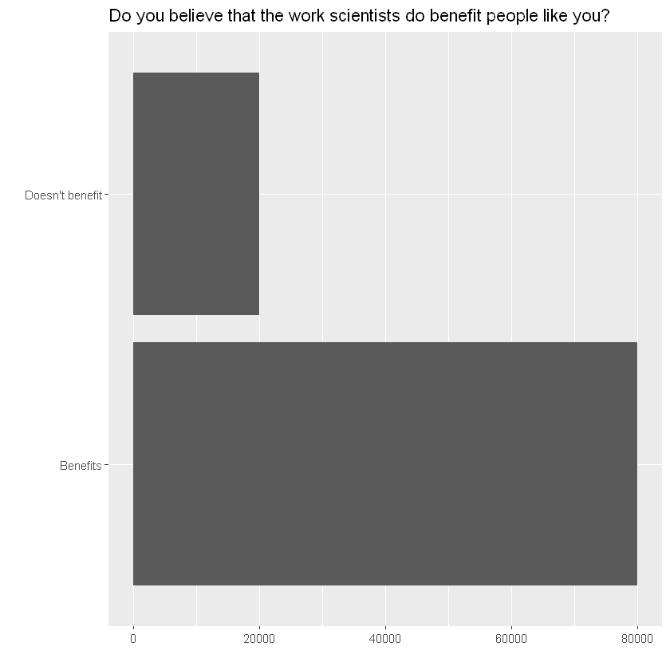

```r
ggplot(data=global_monitor, aes(x = scientist_work)) +
  geom_bar() +
  labs( x = "", y = "",
        title = "Do you believe that the work scientists do benefit people like you?") +
  coord_flip()
```

**3. Obtain summary statistics to confirm we constructed the data frame correctly.**

```r
global_monitor %>%
  count(scientist_work) %>%
  mutate(p = n /sum(n))
```

A tibble: 2 × 3

| scientist_work <chr> | n <int> | p <dbl> |
| --- | --- | --- |
| Benefits | 80000 | 0.8 |
| Doesn't benefit | 20000 | 0.2 |

## The sampling distribution

- gathering information on an entire population is often extremely costly or impossible.
- take a sample of the population and use that to understand the properties of the population.

If you are interested in estimating the proportion of people who don't think the work scientists do benefits them,

- use the `sample_n` function to survey the population.

```r
samp1 <- global_monitor %>%
  sample_n(50)
```

- collects a simple random sample of size 50 from the `global_monitor` dataset, and
- assigns the result to `samp1`.

> similar to randomly drawing names from a hat that contains the names of all in the population.

> Working with these 50 names is considerably simpler than working with all 100,000 people in the population.

#### **Problem 1 :**

Describe the distribution of responses in this sample. How does it compare to the distribution of responses in the population.

**Hint:**

- Although the `sample_n` function takes a random sample of observations (i.e. rows) from the dataset, you can still refer to the variables in the dataset with the same names.
- Code you presented earlier for visualizing and summarising the population data will still be useful for the sample,
- however be careful to not label your proportion `p` since you're now calculating a sample statistic, not a population parameters.
- You can customize the label of the statistics to indicate that it comes from the sample.

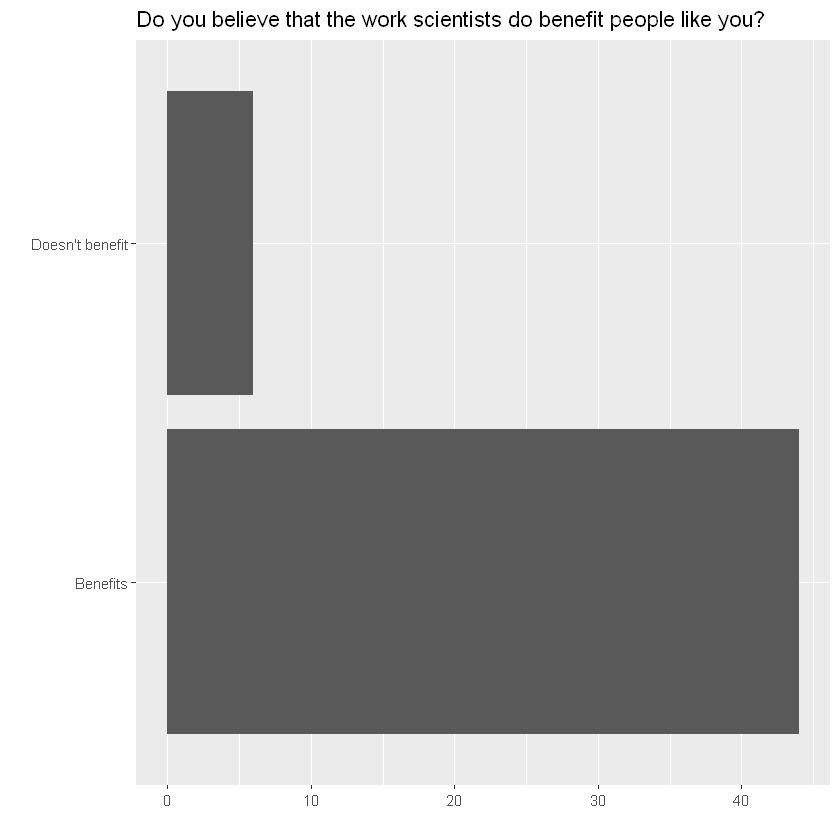

```r
ggplot(samp1, aes(x = scientist_work)) +
  geom_bar() +
  labs( x = "", y = "",
        title = "Do you believe that the work scientists do benefit people like you?") +
  coord_flip()
```

**Interest** : estimation of the **proportion** of all people who do not believe that the work scientists do benefits them,

best single guess - the **sample mean** (or **sample proportion**).

```r
samp1 %>%
  count(scientist_work) %>%
  mutate(p_hat = n /sum(n))
```

A tibble: 2 × 3

| scientist_work <chr> | n <int> | p_hat <dbl> |
| --- | --- | --- |
| Benefits | 44 | 0.88 |
| Doesn't benefit | 6 | 0.12 |

*Depending on which 50 people you selected*, the estimate could be a bit above or a bit below the true population proportion.

> Would you expect the sample proportion to match the sample proportion of another student's sample? Why, or why not? If the answer is no, would you expect the proportions to be somewhat different or very different?

Take a second sample, also of size 50, and call it `samp2`. How does the sample proportion of `samp2` compare with that of `samp1`?

```r
samp2 <- global_monitor %>%
  sample_n(50)
```

```r
samp2 %>%
  count(scientist_work) %>%
  mutate(p_hat = n /sum(n))
```

A tibble: 2 × 3

| scientist_work <chr> | n <int> | p_hat <dbl> |
| --- | --- | --- |
| Benefits | 41 | 0.82 |
| Doesn't benefit | 9 | 0.18 |

Suppose we took two more samples, one of size 100 and one of size 1000. Which would you think would provide a more accurate estimate of the population proportion?

every time you take another random sample, you might get **a different sample proportion**.

the distribution of sample proportions, called the **sampling distribution** (of the proportion), can help you understand how much **variability** you should expect when estimating the population mean.

**The sampling distribution of the sample proportion**

take 15,000 different samples of size 50 from the population,

calculate the proportion of responses in each sample,

filter for only the **Doesn't benefit** responses, and

store each result in a vector called sample_props50

visualize the distribution of these proportions with a histogram.

```r
sample_props50 <- global_monitor %>%
                    rep_sample_n(size = 50, reps = 15000, replace = TRUE) %>%
                    count(scientist_work) %>%
                    mutate(p_hat = n /sum(n)) %>%
                    filter(scientist_work == "Doesn't benefit")
```

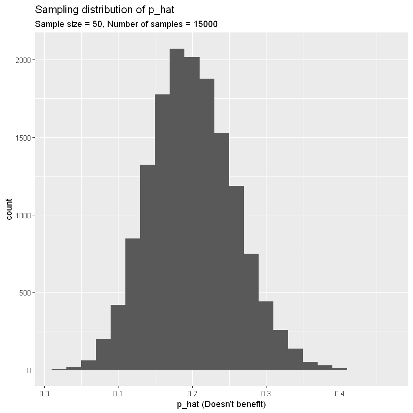

```r
ggplot(data = sample_props50, aes(x = p_hat)) +
  geom_histogram(binwidth = 0.02) +
  labs(
    x = "p_hat (Doesn't benefit)",
    title = "Sampling distribution of p_hat",
    subtitle = "Sample size = 50, Number of samples = 15000"
  )
```

**Note** that we specify that `replace = TRUE` since sampling distributions are constructed by sampling with replacement.

#### **Problem 2 :**

How many elements are there in `sample_props50`? Describe the sampling distribution, and be sure to specifically note its center.

```r
glimpse(sample_props50)
```

```
Observations: 15,000
Variables: 4
Groups: replicate [15,000]
$ replicate      <int> 1, 2, 3, 4, 5, 6, 7, 8, 9, 10, 11, 12, 13, 14, 15, 1...
$ scientist_work <chr> "Doesn't benefit", "Doesn't benefit", "Doesn't benef...
$ n              <int> 13, 12, 13, 12, 10, 10, 10, 9, 8, 9, 9, 7, 10, 17, 1...
$ p_hat          <dbl> 0.26, 0.24, 0.26, 0.24, 0.20, 0.20, 0.20, 0.18, 0.16...
```

```r
mean(sample_props50$p_hat)
```

0.2002

`rep_sample_n` function : repeat the sampling procedure `rep` times in order to build a distribution of a series of sample statistics, which is called the **sampling distribution**.

**Note** that in practice one rarely gets to build true sampling distributions, because one rarely has access to data from the entire population.

To make sure you understand how sampling distributions are built, and exactly what the `rep_sample_n` function does,

#### **Problem 3 :**

- try modifying the code to create a sampling distribution of **25 sample proportions from samples of size 10**, and
- put them in a data frame named `sample_props_small`.
- Print the output.

```r
sample_props_small <- global_monitor %>%
                    rep_sample_n(size = 10, reps = 25, replace = TRUE) %>%
                    count(scientist_work) %>%
                    mutate(p_hat = n /sum(n)) %>%
                    filter(scientist_work == "Doesn't benefit")
sample_props_small
```

A grouped_df: 22 × 4

| replicate <int> | scientist_work <chr> | n <int> | p_hat <dbl> |
| --- | --- | --- | --- |
| 2 | Doesn't benefit | 1 | 0.1 |
| 3 | Doesn't benefit | 3 | 0.3 |
| 4 | Doesn't benefit | 3 | 0.3 |
| 5 | Doesn't benefit | 3 | 0.3 |
| 6 | Doesn't benefit | 4 | 0.4 |
| 7 | Doesn't benefit | 1 | 0.1 |
| 8 | Doesn't benefit | 2 | 0.2 |
| 9 | Doesn't benefit | 2 | 0.2 |
| 10 | Doesn't benefit | 2 | 0.2 |
| 11 | Doesn't benefit | 1 | 0.1 |
| 12 | Doesn't benefit | 2 | 0.2 |
| 13 | Doesn't benefit | 4 | 0.4 |
| 15 | Doesn't benefit | 1 | 0.1 |
| 16 | Doesn't benefit | 1 | 0.1 |
| 17 | Doesn't benefit | 2 | 0.2 |
| 18 | Doesn't benefit | 2 | 0.2 |
| 19 | Doesn't benefit | 3 | 0.3 |
| 20 | Doesn't benefit | 2 | 0.2 |
| 21 | Doesn't benefit | 3 | 0.3 |
| 22 | Doesn't benefit | 5 | 0.5 |
| 24 | Doesn't benefit | 2 | 0.2 |
| 25 | Doesn't benefit | 2 | 0.2 |

> - How many observations are there in this object called `sample_props_small`?
> - What does each observation represent?

## Sample size and the sampling distribution

### the sampling distribution of the proportions from samples of 50 people.

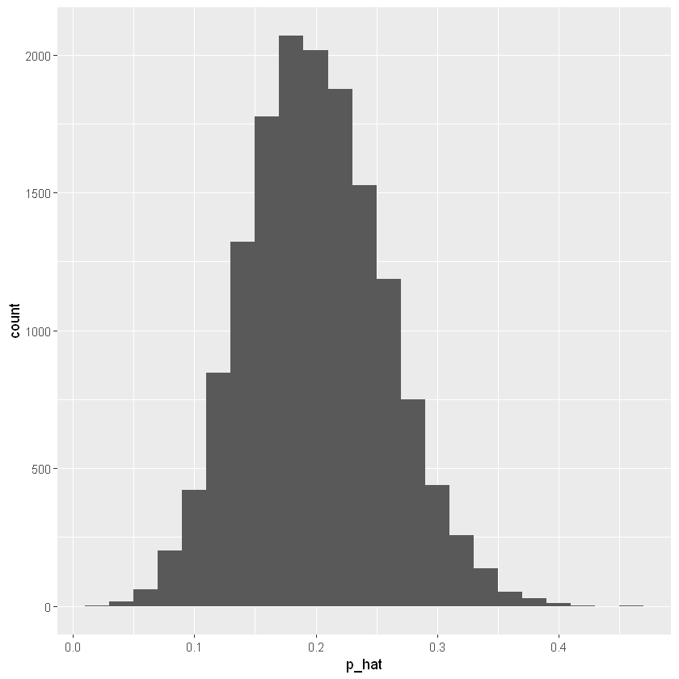

```r
ggplot(data = sample_props50, aes(x = p_hat)) +
  geom_histogram(binwidth = 0.02)
```

- the sampling distribution of the sample proportion is centered at the true population proportion, and
- the spread of the distribution indicates how much variability is incurred by sampling only 50 people at a time from the population.

### the effect of sample size on your sampling distribution

Create sampling distributions of proportions of *Doesn't benefit* from 5,000 samples of size 10, 50, and 100.

```r
sample_props10 <- global_monitor %>%
                    rep_sample_n(size = 10, reps = 5000, replace = TRUE) %>%
                    count(scientist_work) %>%
                    mutate(p_hat = n /sum(n)) %>%
                    filter(scientist_work == "Doesn't benefit")

sample_props50 <- global_monitor %>%
                    rep_sample_n(size = 50, reps = 5000, replace = TRUE) %>%
                    count(scientist_work) %>%
                    mutate(p_hat = n /sum(n)) %>%
                    filter(scientist_work == "Doesn't benefit")

sample_props100 <- global_monitor %>%
                    rep_sample_n(size = 100, reps = 5000, replace = TRUE) %>%
                    count(scientist_work) %>%
                    mutate(p_hat = n /sum(n)) %>%
                    filter(scientist_work == "Doesn't benefit")
```

- What does each observation in the sampling distribution represent?
- How does the mean, standar error, and shape of the sampling distribution change as the sample size increases?
- How (if at all) do these values change if you increase the number of simulations?

```r
mean(sample_props10$p_hat)
sd(sample_props10$p_hat)

mean(sample_props50$p_hat)
sd(sample_props50$p_hat)

mean(sample_props100$p_hat)
sd(sample_props100$p_hat)
```

0.220485956308515

0.111268494876661

0.200332

0.0560324700824505

0.200022

0.0399487008016424

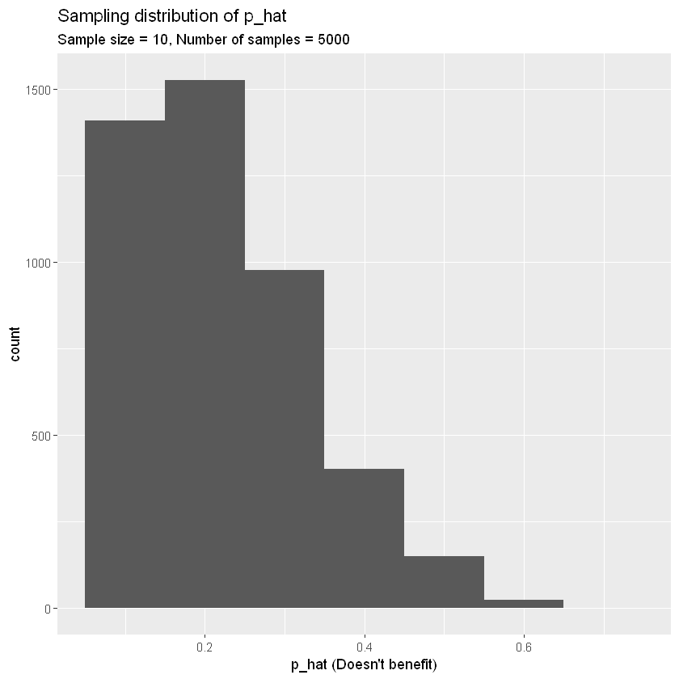

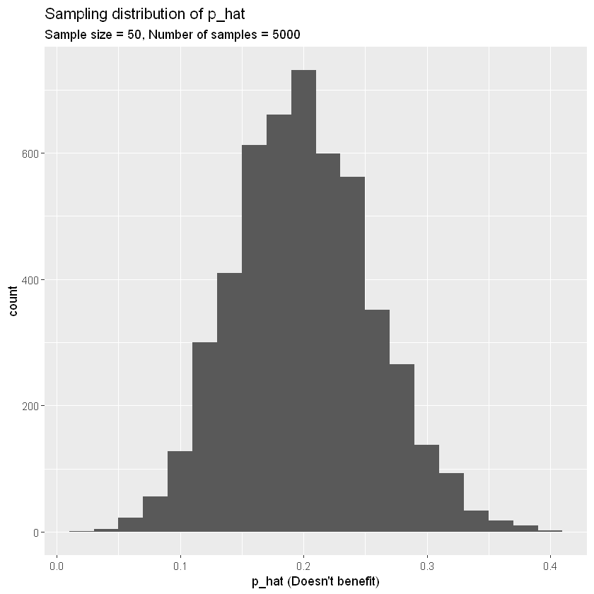

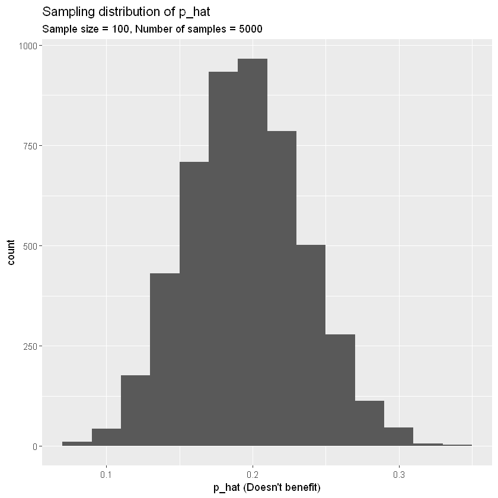

```r
ggplot(data = sample_props10, aes(x = p_hat)) +
  geom_histogram(binwidth = 0.1)+
  labs(
    x = "p_hat (Doesn't benefit)",
    title = "Sampling distribution of p_hat",
    subtitle = "Sample size = 10, Number of samples = 5000"
  )

ggplot(data = sample_props50, aes(x = p_hat)) +
  geom_histogram(binwidth = 0.02)+
  labs(
    x = "p_hat (Doesn't benefit)",
    title = "Sampling distribution of p_hat",
    subtitle = "Sample size = 50, Number of samples = 5000"
  )

ggplot(data = sample_props100, aes(x = p_hat)) +
  geom_histogram(binwidth = 0.02)+
  labs(
    x = "p_hat (Doesn't benefit)",
    title = "Sampling distribution of p_hat",
    subtitle = "Sample size = 100, Number of samples = 5000"
  )
```

## Assignment

1. 2000 samples of size 15.
   - simulate the sampling distribution of proportion of those who think the work scientists do enchances their lives for *samples of size 15* by taking *2000 samples* from the population of size 15
   - compute 2000 sample proportions.
   - store these proportions in as `sample_props15`.
   - plot the data
   - describe the shape of this sampling distribution.

> Based on this sampling distribution, what would you guess the true proportion of those who think the work scientists do enchances their lives to be?

> Finally, calculate and report the population proportion.
1. Change your sample size from 15 to 150,
   - compute the sample proportions using the same method as above, and
   - store these proportions in a new object called `sample_props150`.
   - describe the shape of this sampling distribution
   - compare it to the sampling distribution for a sample size of 15.

> Based on this sampling distribution, what would you guess to be the true proportion of those who think the work scientists do enchances their lives?
1. Of the sampling distributions from 2 and 3, which has a smaller spread? If you're concerned with making estimates that are more often close to the true value, would you prefer a sampling distribution with a large or small spread?

This work is licensed under a [Creative Commons Attribution-ShareAlike 4.0 International License](http://creativecommons.org/licenses/by-sa/4.0/).